# Hyper - Carlsberg

Andreas Borup Joergensen, Mette Koch Moeller, Robert Hoestrup

Downloading the packages

```r
library(tidyverse) #Collection of all the good stuff like dplyr, ggplot2 ect.
library(magrittr) #For advanced piping
library(kerastuneR) #For hyper tuning ANN models
library(keras) #For ANN models
library(tidymodels)
library(ggpubr) #package that helps mixing multiple plots on the same page
```

Downloading the data directly from github

```r
data <- read_csv("https://raw.githubusercontent.com/andreasbj77/Master-thesis/main/Data/DataCreationCarlsberg.csv")
```

The data contains the date, the response variable and the features we have decided to use.

```r
data %>% glimpse()
```

```
FALSE Rows: 2,494
FALSE Columns: 8
FALSE $ Date       <date> 2010-01-04, 2010-01-05, 2010-01-06, 2010-01-07, 2010-01-08~
FALSE $ Carlsberg  <dbl> 393.00, 394.85, 388.00, 392.00, 393.00, 400.00, 395.00, 395~
FALSE $ DanskeBank <dbl> 111.97, 115.67, 117.06, 120.76, 122.61, 125.29, 124.46, 123~
FALSE $ DSV        <dbl> 96.00, 95.95, 100.50, 101.00, 101.70, 104.00, 102.00, 99.50~
FALSE $ GN         <dbl> 29.7, 29.3, 28.4, 29.5, 29.5, 29.3, 29.5, 29.8, 30.4, 30.3,~
FALSE $ JyskeBank  <dbl> 205.0, 204.1, 203.4, 210.4, 210.7, 210.0, 209.1, 207.8, 213~
FALSE $ Tryg       <dbl> 70.30, 68.80, 68.20, 67.06, 67.86, 67.74, 67.82, 66.60, 67.~
FALSE $ OilPrice   <dbl> 420.560, 423.460, 429.450, 429.260, 427.290, 423.240, 415.2~
```

# Pre-processing

The variable is scaled and made numeric. This is done because its generally easier for RNNs to learn from scaled data. The scaling attribute attr is saved in order to be able to unscale the data later.

```r
data$Carlsberg %<>% scale(center = FALSE, scale = TRUE)
data$DanskeBank %<>% scale(center = FALSE, scale = TRUE)
data$DSV %<>% scale(center = FALSE, scale = TRUE)
data$GN %<>% scale(center = FALSE, scale = TRUE)
data$JyskeBank %<>% scale(center = FALSE, scale = TRUE)
data$Tryg %<>% scale(center = FALSE, scale = TRUE)
data$OilPrice %<>% scale(center = FALSE, scale = TRUE)

att_Carlsberg <- attr(data$Carlsberg, 'scaled:scale')

data$Carlsberg %<>% as.numeric()
data$DanskeBank %<>% as.numeric()
data$DSV %<>% as.numeric()
data$GN %<>% as.numeric()
data$JyskeBank %<>% as.numeric()
data$Tryg %<>% as.numeric()
data$OilPrice %<>% as.numeric()
```

We check the data to make sure it is all scaled properly

```r
data %>% glimpse()
```

```
FALSE Rows: 2,494
FALSE Columns: 8
FALSE $ Date       <date> 2010-01-04, 2010-01-05, 2010-01-06, 2010-01-07, 2010-01-08~
FALSE $ Carlsberg  <dbl> 0.6313278, 0.6342997, 0.6232956, 0.6297214, 0.6313278, 0.64~
FALSE $ DanskeBank <dbl> 0.7029316, 0.7261597, 0.7348859, 0.7581140, 0.7697280, 0.78~
FALSE $ DSV        <dbl> 0.2939447, 0.2937916, 0.3077233, 0.3092543, 0.3113976, 0.31~
FALSE $ GN         <dbl> 0.1798719, 0.1774494, 0.1719988, 0.1786607, 0.1786607, 0.17~
FALSE $ JyskeBank  <dbl> 0.7429444, 0.7396827, 0.7371458, 0.7625147, 0.7636019, 0.76~
FALSE $ Tryg       <dbl> 0.5703264, 0.5581573, 0.5532897, 0.5440411, 0.5505313, 0.54~
FALSE $ OilPrice   <dbl> 0.9501277, 0.9566794, 0.9702119, 0.9697827, 0.9653321, 0.95~
```

The variables needed to forecast Carlsberg is selected from the complete data set

```r
data_Carlsberg <- data
```

## Out-of-Sample-Testing

```r
training <- data_Carlsberg %>% filter(Date <= "2017-12-29")
testing <- data_Carlsberg %>% filter(Date > "2017-12-29" & Date <= "2018-12-28")
```

The data sets are divided into the response and explanatory variables. Here a lead of Carlsberg acts as the response variable.

```r
#Train data
x_train <- training %>%
  select(-Date) %>%
  as.matrix()

y_train <- training %>%
  select(-Date) %>%
  mutate(Carlsberg = Carlsberg %>% lead(1)) %>%
  mutate(Carlsberg = ifelse(is.na(Carlsberg), lag(Carlsberg, 1), Carlsberg)) %>%
  select(Carlsberg) %>%
  as.matrix()

#Test data
x_test <- testing %>%
  select(-Date) %>%
  as.matrix()

y_test <- testing %>%
  select(-Date) %>%
  mutate(Carlsberg = Carlsberg %>% lead(1)) %>%
  mutate(Carlsberg = ifelse(is.na(Carlsberg), lag(Carlsberg, 1), Carlsberg)) %>%
  select(Carlsberg) %>%
  as.matrix()
```

## Creating time series generators

```r
n_input = 15  # amount of timesteps in the model
n_features = ncol(data_Carlsberg) - 1 # amount of explanatory variables
b_size = 64 # amount of data points going through at the same time
step_train = (nrow(training)/b_size) %>% round(0) # Steps is equals to the amount that sends all data through the model once per epoch
step_test = (nrow(testing)/b_size) %>% round(0) # Steps is equals to the amount that sends all data through the model once per epoch


# Generator for training
training_generator = timeseries_generator(x_train,
                                 y_train,
                                 length = n_input,
                                 batch_size = b_size)

# Generator for testing
test_generator = timeseries_generator(x_test,
                                 y_test,
                                 length = n_input,
                                 batch_size = b_size)
```

# Creating models

## FNN

```r
build_model <- function(hp) {

  model <- keras_model_sequential()
  model %>% layer_dense(units = hp$Int('units',
                                       min_value =32,
                                       max_value = 1024,
                                       step = 32),
                        input_shape = ncol(x_train),
                        activation = "relu") %>%
            layer_dropout(rate = hp$Choice("dropout_rate", values = c(0, 0.1, 0.2, 0.3)))
      for (i in 1:(hp$Int('num_layers', 1L, 5L)) ) {
     model %>% layer_dense(units = hp$Int(paste0("units",i),
                                       min_value =32,
                                       max_value = 1024,
                                       step = 32),
                        activation= "relu") %>%
               layer_dropout(rate = hp$Choice(paste0("dropout_rate",i), values = c(0, 0.1, 0.2, 0.3)))
      }
     model %>% layer_dense(units = 1) %>%
    compile(
      optimizer = tf$keras$optimizers$Adam(
        hp$Choice("learning_rate",
                  values = c(1e-2, 1e-3, 1e-4))),
      loss = "mse",
      metric = "mape")
  return(model)
}
```

```r
tuner <- Hyperband(
  build_model,
  objective = "val_mape",
  max_epochs = 10,
  project_name = "Carlsberg_hyper_FNN")
```

```r
tuner %>% search_summary()
```

```r
system.time({
tuner %>% fit_tuner(x = x_train, #training the model
                    y = y_train,
                    epochs = 5,
                    validation_split = 0.10,
                    shuffle = TRUE,
                    initial_epoch = 0,
                    use_multiprocessing = TRUE,
                    workers = 7,
                    verbose = 0)
})
```

```
FALSE    user  system elapsed
FALSE       0       0       0
```

```r
model_ANN <- tuner %>% get_best_models(1)
model_ANN <- model_ANN[[1]]
```

```r
model_ANN %>% summary
```

```
FALSE Model: "sequential"
FALSE ________________________________________________________________________________
FALSE Layer (type)                        Output Shape                    Param #
FALSE ================================================================================
FALSE dense (Dense)                       (None, 608)                     4864
FALSE ________________________________________________________________________________
FALSE dropout (Dropout)                   (None, 608)                     0
FALSE ________________________________________________________________________________
FALSE dense_1 (Dense)                     (None, 1024)                    623616
FALSE ________________________________________________________________________________
FALSE dropout_1 (Dropout)                 (None, 1024)                    0
FALSE ________________________________________________________________________________
FALSE dense_2 (Dense)                     (None, 256)                     262400
FALSE ________________________________________________________________________________
FALSE dropout_2 (Dropout)                 (None, 256)                     0
FALSE ________________________________________________________________________________
FALSE dense_3 (Dense)                     (None, 1)                       257
FALSE ================================================================================
FALSE Total params: 891,137
FALSE Trainable params: 891,137
FALSE Non-trainable params: 0
FALSE ________________________________________________________________________________
```

```r
rm(tuner, build_model)
```

## RNN

```r
build_model <- function(hp) {

model <- keras_model_sequential()

  model %>% layer_simple_rnn(units = hp$Int('units',
                                       min_value =32,
                                       max_value = 1024,
                                       step = 32),
                        input_shape = c(n_input, n_features),
                        activation = hp$Choice("RNN_activation", values = c("relu", "tanh")), return_sequences = FALSE)
  for (i in 1:(hp$Int('num_layers', 1L, 5L)) ) {
     model %>% layer_dense(units = hp$Int(paste0("units",i),
                                       min_value =32,
                                       max_value = 1024,
                                       step = 32),
                        activation= "relu") %>%
               layer_dropout(rate = hp$Choice(paste0("dropout_rate",i), values = c(0, 0.1, 0.2, 0.3)))
      }
     model %>% layer_dense(units = 1) %>%
    compile(
      optimizer = tf$keras$optimizers$Adam(
        hp$Choice("learning_rate",
                  values = c(1e-2, 1e-3, 1e-4))),
      loss = "mse",
      metric = "mape")
  return(model)
}
```

```r
tuner <- Hyperband(
  build_model,
  objective = "val_mape",
  max_epochs = 30,
  project_name = "Carlsberg_hyper_RNN")
```

```r
tuner %>% search_summary()
```

```r
system.time({
tuner %>% fit_tuner(training_generator,
              epochs = 10,
              steps_per_epoch = step_train,
              validation_data = test_generator,
              validation_steps = step_test,
              initial_epoch = 0,
              verbose = 0)
})
```

```
FALSE    user  system elapsed
FALSE       0       0       0
```

```r
model_RNN <- tuner %>% get_best_models(1)
model_RNN <- model_RNN[[1]]
```

```r
model_RNN %>% summary
```

```
FALSE Model: "sequential"
FALSE ________________________________________________________________________________
FALSE Layer (type)                        Output Shape                    Param #
FALSE ================================================================================
FALSE simple_rnn (SimpleRNN)              (None, 576)                     336384
FALSE ________________________________________________________________________________
FALSE dense (Dense)                       (None, 1024)                    590848
FALSE ________________________________________________________________________________
FALSE dropout (Dropout)                   (None, 1024)                    0
FALSE ________________________________________________________________________________
FALSE dense_1 (Dense)                     (None, 864)                     885600
FALSE ________________________________________________________________________________
FALSE dropout_1 (Dropout)                 (None, 864)                     0
FALSE ________________________________________________________________________________
FALSE dense_2 (Dense)                     (None, 960)                     830400
FALSE ________________________________________________________________________________
FALSE dropout_2 (Dropout)                 (None, 960)                     0
FALSE ________________________________________________________________________________
FALSE dense_3 (Dense)                     (None, 416)                     399776
FALSE ________________________________________________________________________________
FALSE dropout_3 (Dropout)                 (None, 416)                     0
FALSE ________________________________________________________________________________
FALSE dense_4 (Dense)                     (None, 96)                      40032
FALSE ________________________________________________________________________________
FALSE dropout_4 (Dropout)                 (None, 96)                      0
FALSE ________________________________________________________________________________
FALSE dense_5 (Dense)                     (None, 1)                       97
FALSE ================================================================================
FALSE Total params: 3,083,137
FALSE Trainable params: 3,083,137
FALSE Non-trainable params: 0
FALSE ________________________________________________________________________________
```

```r
rm(tuner, build_model)
```

## LSTM

```r
build_model <- function(hp) {

model <- keras_model_sequential()

  model %>% layer_lstm(units = hp$Int('units',
                                       min_value =32,
                                       max_value = 1024,
                                       step = 32),
                        input_shape = c(n_input, n_features),
                        activation = hp$Choice("lstm_activation", values = c("relu", "tanh")), return_sequences = FALSE)
  for (i in 1:(hp$Int('num_layers', 1L, 5L)) ) {
     model %>% layer_dense(units = hp$Int(paste0("units",i),
                                       min_value =32,
                                       max_value = 1024,
                                       step = 32),
                        activation= "relu") %>%
               layer_dropout(rate = hp$Choice(paste0("dropout_rate",i), values = c(0, 0.1, 0.2, 0.3)))
      }
     model %>% layer_dense(units = 1) %>%
    compile(
      optimizer = tf$keras$optimizers$Adam(
        hp$Choice("learning_rate",
                  values = c(1e-2, 1e-3, 1e-4))),
      loss = "mse",
      metric = "mape")
  return(model)
}
```

```r
tuner <- Hyperband(
  build_model,
  objective = "val_mape",
  max_epochs = 30,
  project_name = "Carlsberg_hyper_LSTM")
```

```r
tuner %>% search_summary()
```

```r
system.time({
tuner %>% fit_tuner(training_generator,
              epochs = 10,
              steps_per_epoch = step_train,
              validation_data = test_generator,
              validation_steps = step_test,
              initial_epoch = 0,
              verbose = 0)
})
```

```
FALSE    user  system elapsed
FALSE       0       0       0
```

```r
model_LSTM <- tuner %>% get_best_models(1)
model_LSTM <- model_LSTM[[1]]
```

```r
model_LSTM %>% summary
```

```
FALSE Model: "sequential"
FALSE ________________________________________________________________________________
FALSE Layer (type)                        Output Shape                    Param #
FALSE ================================================================================
FALSE lstm (LSTM)                         (None, 384)                     602112
FALSE ________________________________________________________________________________
FALSE dense (Dense)                       (None, 896)                     344960
FALSE ________________________________________________________________________________
FALSE dropout (Dropout)                   (None, 896)                     0
FALSE ________________________________________________________________________________
FALSE dense_1 (Dense)                     (None, 672)                     602784
FALSE ________________________________________________________________________________
FALSE dropout_1 (Dropout)                 (None, 672)                     0
FALSE ________________________________________________________________________________
FALSE dense_2 (Dense)                     (None, 1)                       673
FALSE ================================================================================
FALSE Total params: 1,550,529
FALSE Trainable params: 1,550,529
FALSE Non-trainable params: 0
FALSE ________________________________________________________________________________
```

```r
rm(tuner, build_model)
```

## Bi-directional LSTM

```r
build_model <- function(hp) {

model <- keras_model_sequential()

  model %>% bidirectional(
            layer_lstm(units = hp$Int('units',
                                       min_value =32,
                                       max_value = 1024,
                                       step = 32),
                       input_shape = c(n_input, n_features),
                       activation = hp$Choice("lstm_activation",
                                              values = c("relu", "tanh")),
                       return_sequences = FALSE))
  for (i in 1:(hp$Int('num_layers', 1L, 5L)) ) {
     model %>% layer_dense(units = hp$Int(paste0("units",i),
                                       min_value =32,
                                       max_value = 1024,
                                       step = 32),
                        activation= "relu") %>%
               layer_dropout(rate = hp$Choice(paste0("dropout_rate",i), values = c(0, 0.1, 0.2, 0.3)))
      }
     model %>% layer_dense(units = 1) %>%
    compile(
      optimizer = tf$keras$optimizers$Adam(
        hp$Choice("learning_rate",
                  values = c(1e-2, 1e-3, 1e-4))),
      loss = "mse",
      metric = "mape")
  return(model)
}
```

```r
tuner <- Hyperband(
  build_model,
  objective = "val_mape",
  max_epochs = 30,
  project_name = "Carlsberg_hyper_biLSTM")
```

```r
tuner %>% search_summary()
```

```r
system.time({
tuner %>% fit_tuner(training_generator,
              epochs = 10,
              steps_per_epoch = step_train,
              validation_data = test_generator,
              validation_steps = step_test,
              initial_epoch = 0,
              verbose = 0)
})
```

```
FALSE    user  system elapsed
FALSE       0       0       0
```

```r
model_biLSTM <- tuner %>% get_best_models(1)
model_biLSTM <- model_biLSTM[[1]]
```

```r
model_biLSTM %>% evaluate_generator(test_generator, steps = step_test)
```

```
FALSE        loss        mape
FALSE 0.000667315 1.741633296
```

```r
model_biLSTM %>% summary
```

```
FALSE Model: "sequential"
FALSE ________________________________________________________________________________
FALSE Layer (type)                        Output Shape                    Param #
FALSE ================================================================================
FALSE bidirectional (Bidirectional)       multiple                        5171200
FALSE ________________________________________________________________________________
FALSE dense (Dense)                       multiple                        1178336
FALSE ________________________________________________________________________________
FALSE dropout (Dropout)                   multiple                        0
FALSE ________________________________________________________________________________
FALSE dense_1 (Dense)                     multiple                        542432
FALSE ________________________________________________________________________________
FALSE dropout_1 (Dropout)                 multiple                        0
FALSE ________________________________________________________________________________
FALSE dense_2 (Dense)                     multiple                        424512
FALSE ________________________________________________________________________________
FALSE dropout_2 (Dropout)                 multiple                        0
FALSE ________________________________________________________________________________
FALSE dense_3 (Dense)                     multiple                        577
FALSE ================================================================================
FALSE Total params: 7,317,057
FALSE Trainable params: 7,317,057
FALSE Non-trainable params: 0
FALSE ________________________________________________________________________________
```

```r
rm(tuner, build_model)
```

## GRU

```r
build_model <- function(hp) {

model <- keras_model_sequential()

  model %>% layer_gru(units = hp$Int('units',
                                       min_value =32,
                                       max_value = 1024,
                                       step = 32),
                        input_shape = c(n_input, n_features),
                        activation = hp$Choice("GRU_activation", values = c("relu", "tanh")), return_sequences = FALSE)
  for (i in 1:(hp$Int('num_layers', 1L, 5L)) ) {
     model %>% layer_dense(units = hp$Int(paste0("units",i),
                                       min_value =32,
                                       max_value = 1024,
                                       step = 32),
                        activation= "relu") %>%
               layer_dropout(rate = hp$Choice(paste0("dropout_rate",i), values = c(0, 0.1, 0.2, 0.3)))
      }
     model %>% layer_dense(units = 1) %>%
    compile(
      optimizer = tf$keras$optimizers$Adam(
        hp$Choice("learning_rate",
                  values = c(1e-2, 1e-3, 1e-4))),
      loss = "mse",
      metric = "mape")
  return(model)
}
```

```r
tuner <- Hyperband(
  build_model,
  objective = "val_mape",
  max_epochs = 30,
  project_name = "Carlsberg_hyper_GRU")
```

```r
tuner %>% search_summary()
```

```r
system.time({
tuner %>% fit_tuner(training_generator,
              epochs = 10,
              steps_per_epoch = step_train,
              validation_data = test_generator,
              validation_steps = step_test,
              initial_epoch = 0,
              use_multiprocessing = TRUE,
              workers = 7,
              verbose = 0)
})
```

```
FALSE    user  system elapsed
FALSE    0.01    0.00    0.02
```

```r
model_GRU <- tuner %>% get_best_models(1)
model_GRU <- model_GRU[[1]]
```

```r
model_GRU %>% summary
```

```
FALSE Model: "sequential"
FALSE ________________________________________________________________________________
FALSE Layer (type)                        Output Shape                    Param #
FALSE ================================================================================
FALSE gru (GRU)                           (None, 576)                     1009152
FALSE ________________________________________________________________________________
FALSE dense (Dense)                       (None, 736)                     424672
FALSE ________________________________________________________________________________
FALSE dropout (Dropout)                   (None, 736)                     0
FALSE ________________________________________________________________________________
FALSE dense_1 (Dense)                     (None, 128)                     94336
FALSE ________________________________________________________________________________
FALSE dropout_1 (Dropout)                 (None, 128)                     0
FALSE ________________________________________________________________________________
FALSE dense_2 (Dense)                     (None, 1)                       129
FALSE ================================================================================
FALSE Total params: 1,528,289
FALSE Trainable params: 1,528,289
FALSE Non-trainable params: 0
FALSE ________________________________________________________________________________
```

```r
rm(tuner, build_model)
```

## Bi-directional GRU

```r
build_model <- function(hp) {

model <- keras_model_sequential()

  model %>% bidirectional(
            layer_gru(units = hp$Int('units',
                                       min_value =32,
                                       max_value = 1024,
                                       step = 32),
                       input_shape = c(n_input, n_features),
                       activation = hp$Choice("lstm_activation",
                                              values = c("relu", "tanh")),
                       return_sequences = FALSE))
  for (i in 1:(hp$Int('num_layers', 1L, 5L)) ) {
     model %>% layer_dense(units = hp$Int(paste0("units",i),
                                       min_value =32,
                                       max_value = 1024,
                                       step = 32),
                        activation= "relu") %>%
               layer_dropout(rate = hp$Choice(paste0("dropout_rate",i), values = c(0, 0.1, 0.2, 0.3)))
      }
     model %>% layer_dense(units = 1) %>%
    compile(
      optimizer = tf$keras$optimizers$Adam(
        hp$Choice("learning_rate",
                  values = c(1e-2, 1e-3, 1e-4))),
      loss = "mse",
      metric = "mape")
  return(model)
}
```

```r
tuner <- Hyperband(
  build_model,
  objective = "val_mape",
  max_epochs = 30,
  project_name = "Carlsberg_hyper_biGRU")
```

```r
tuner %>% search_summary()
```

```r
system.time({
tuner %>% fit_tuner(training_generator,
              epochs = 10,
              steps_per_epoch = step_train,
              validation_data = test_generator,
              validation_steps = step_test,
              initial_epoch = 0,
              verbose = 0)
})
```

```
FALSE    user  system elapsed
FALSE       0       0       0
```

```r
model_biGRU <- tuner %>% get_best_models(1)
model_biGRU <- model_biGRU[[1]]
```

```r
model_biGRU %>% summary
```

```
FALSE Model: "sequential"
FALSE ________________________________________________________________________________
FALSE Layer (type)                        Output Shape                    Param #
FALSE ================================================================================
FALSE bidirectional (Bidirectional)       multiple                        59904
FALSE ________________________________________________________________________________
FALSE dense (Dense)                       multiple                        49408
FALSE ________________________________________________________________________________
FALSE dropout (Dropout)                   multiple                        0
FALSE ________________________________________________________________________________
FALSE dense_1 (Dense)                     multiple                        257
FALSE ================================================================================
FALSE Total params: 109,569
FALSE Trainable params: 109,569
FALSE Non-trainable params: 0
FALSE ________________________________________________________________________________
```

# Results

```r
ANN_prediction <- model_ANN %>% predict(x_test)
RNN_prediction <- predict_generator(model_RNN, test_generator, steps = step_test)
LSTM_prediction <-predict_generator(model_LSTM, test_generator, steps = step_test)
biLSTM_prediction <-predict_generator(model_biLSTM, test_generator, steps = step_test)
GRU_prediction <-predict_generator(model_GRU, test_generator, steps = step_test)
biGRU_prediction <-predict_generator(model_biGRU, test_generator, steps = step_test)
```

```r
ANN_prediction_unscale <- ANN_prediction * att_Carlsberg
RNN_prediction_unscale <- RNN_prediction * att_Carlsberg
LSTM_prediction_unscale <- LSTM_prediction * att_Carlsberg
biLSTM_prediction_unscale <- biLSTM_prediction * att_Carlsberg
GRU_prediction_unscale <- GRU_prediction * att_Carlsberg
biGRU_prediction_unscale <- biGRU_prediction * att_Carlsberg

y_test_unscale <- y_test * att_Carlsberg
```

```r
start <- n_input + 1

eval_ANN <- tibble(
  Date = testing %>% pull(Date),
  truth = y_test_unscale,
  prediction = ANN_prediction_unscale
)

eval_RNN <- tibble(
  Date = testing[start:nrow(testing),] %>% pull(Date),
  truth = y_test_unscale[start:nrow(testing),],
  prediction = RNN_prediction_unscale
)

eval_LSTM <- tibble(
  Date = testing[start:nrow(testing),] %>% pull(Date),
  truth = y_test_unscale[start:nrow(testing),],
  prediction = LSTM_prediction_unscale
)

eval_biLSTM <- tibble(
  Date = testing[start:nrow(testing),] %>% pull(Date),
  truth = y_test_unscale[start:nrow(testing),],
  prediction = biLSTM_prediction_unscale
)

eval_GRU <- tibble(
  Date = testing[start:nrow(testing),] %>% pull(Date),
  truth = y_test_unscale[start:nrow(testing),],
  prediction = GRU_prediction_unscale
)

eval_biGRU <- tibble(
  Date = testing[start:nrow(testing),] %>% pull(Date),
  truth = y_test_unscale[start:nrow(testing),],
  prediction = biGRU_prediction_unscale
)
```

```r
RMSE_ANN <- eval_ANN %>% rmse(as.numeric(truth), as.numeric(prediction))
MAPE_ANN <- eval_ANN %>% mape(as.numeric(truth), as.numeric(prediction))
RMSE_ANN %<>% rename(RMSE = .estimate)
MAPE_ANN %<>% rename(MAPE = .estimate)
ANN <- cbind(RMSE_ANN, MAPE_ANN)
ANN %<>% select(RMSE, MAPE) %>% mutate(Model = "ANN")

RMSE_RNN <- eval_RNN %>% rmse(as.numeric(truth), as.numeric(prediction))
MAPE_RNN <- eval_RNN %>% mape(as.numeric(truth), as.numeric(prediction))
RMSE_RNN %<>% rename(RMSE = .estimate)
MAPE_RNN %<>% rename(MAPE = .estimate)
RNN <- cbind(RMSE_RNN, MAPE_RNN)
RNN %<>% select(RMSE, MAPE) %>% mutate(Model = "RNN")

RMSE_LSTM <- eval_LSTM %>% rmse(as.numeric(truth), as.numeric(prediction))
MAPE_LSTM <- eval_LSTM %>% mape(as.numeric(truth), as.numeric(prediction))
RMSE_LSTM %<>% rename(RMSE = .estimate)
MAPE_LSTM %<>% rename(MAPE = .estimate)
LSTM <- cbind(RMSE_LSTM, MAPE_LSTM)
LSTM %<>% select(RMSE, MAPE) %>% mutate(Model = "LSTM")

RMSE_biLSTM <- eval_biLSTM %>% rmse(as.numeric(truth), as.numeric(prediction))
MAPE_biLSTM <- eval_biLSTM %>% mape(as.numeric(truth), as.numeric(prediction))
RMSE_biLSTM %<>% rename(RMSE = .estimate)
MAPE_biLSTM %<>% rename(MAPE = .estimate)
biLSTM <- cbind(RMSE_biLSTM, MAPE_biLSTM)
biLSTM %<>% select(RMSE, MAPE) %>% mutate(Model = "biLSTM")

RMSE_gru <- eval_GRU %>% rmse(as.numeric(truth), as.numeric(prediction))
MAPE_gru <- eval_GRU %>% mape(as.numeric(truth), as.numeric(prediction))
RMSE_gru %<>% rename(RMSE = .estimate)
MAPE_gru %<>% rename(MAPE = .estimate)
GRU <- cbind(RMSE_gru, MAPE_gru)
GRU %<>% select(RMSE, MAPE) %>% mutate(Model = "GRU")

RMSE_bigru <- eval_biGRU %>% rmse(as.numeric(truth), as.numeric(prediction))
MAPE_bigru <- eval_biGRU %>% mape(as.numeric(truth), as.numeric(prediction))
RMSE_bigru %<>% rename(RMSE = .estimate)
MAPE_bigru %<>% rename(MAPE = .estimate)
biGRU <- cbind(RMSE_bigru, MAPE_bigru)
biGRU %<>% select(RMSE, MAPE) %>% mutate(Model = "biGRU")
```

The resulting MAPE and RMSE for each of the models are combined in a single data frame

```r
Results <- rbind(ANN, RNN, LSTM, biLSTM, GRU, biGRU)
```

## Testing results

We arrange the results at ascending RMSE to see which model performs best

```r
Results %>% select(Model, RMSE, MAPE) %>% arrange(RMSE)
```

| Model | RMSE | MAPE |
| --- | --- | --- |
| GRU | 12.12465 | 1.339153 |
| RNN | 13.23416 | 1.454942 |
| LSTM | 13.42654 | 1.435417 |
| biGRU | 13.52384 | 1.486695 |
| biLSTM | 16.08063 | 1.741633 |
| ANN | 40.12870 | 4.472497 |

We also plot all the models’ forecast to see how they perform over time

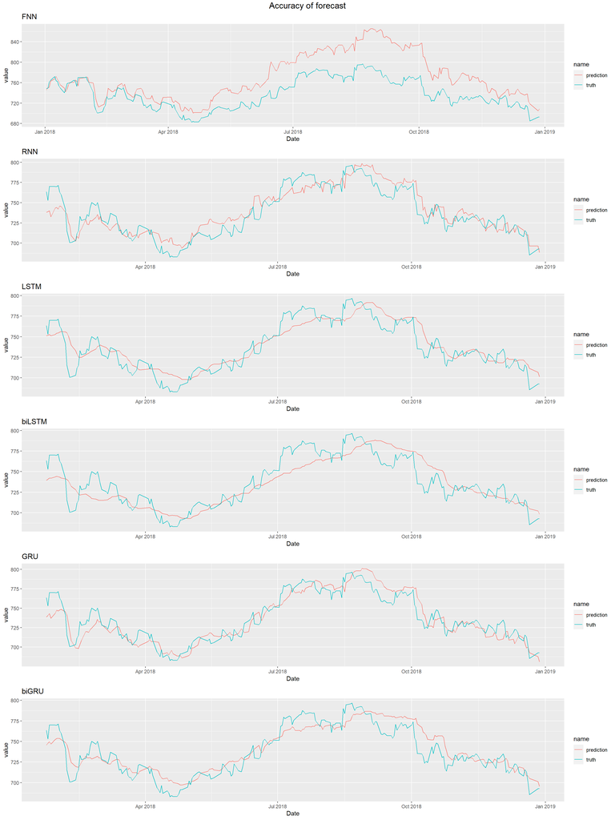

```r
plot_ANN <- eval_ANN %>%
  pivot_longer(-Date) %>%
  ggplot(aes(x = Date, y = value, col = name)) +
  geom_line() +
  ggtitle("FNN")

plot_RNN <- eval_RNN %>%
  pivot_longer(-Date) %>%
  ggplot(aes(x = Date, y = value, col = name)) +
  geom_line() +
  ggtitle("RNN")

plot_LSTM <- eval_LSTM %>%
  pivot_longer(-Date) %>%
  ggplot(aes(x = Date, y = value, col = name)) +
  geom_line() +
  ggtitle("LSTM")

plot_biLSTM <- eval_biLSTM %>%
  pivot_longer(-Date) %>%
  ggplot(aes(x = Date, y = value, col = name)) +
  geom_line() +
  ggtitle("biLSTM")

plot_GRU <- eval_GRU %>%
  pivot_longer(-Date) %>%
  ggplot(aes(x = Date, y = value, col = name)) +
  geom_line() +
  ggtitle("GRU")

plot_biGRU <- eval_biGRU %>%
  pivot_longer(-Date) %>%
  ggplot(aes(x = Date, y = value, col = name)) +
  geom_line() +
  ggtitle("biGRU")

plot <- ggarrange(plot_ANN, plot_RNN, plot_LSTM, plot_biLSTM, plot_GRU, plot_biGRU, ncol = 1)
annotate_figure(plot, top = text_grob("Accuracy of forecast", size = 15))
```

```r
save_model_hdf5(model_ANN, "model_ANN_Carlsberg")
save_model_hdf5(model_RNN, "model_RNN_Carlsberg")
save_model_hdf5(model_LSTM, "model_LSTM_Carlsberg")
save_model_hdf5(model_biLSTM, "model_biLSTM_Carlsberg")
save_model_hdf5(model_GRU, "model_GRU_Carlsberg")
save_model_hdf5(model_biGRU, "model_biGRU_Carlsberg")
Results %>% select(Model, RMSE, MAPE) %>% write.csv("Results_Carlsberg")
```